# Modelação Estocástica - Trabalho 2

## $N (0, 4)$ aproveitando cada 10º valor gerado

Por fim, temos o caso em que o amostrador tem como distribuição candidata uma Normal com desvio padrão bastante superior àqueles observados nos cenários anteriores, $N(0,4)$.

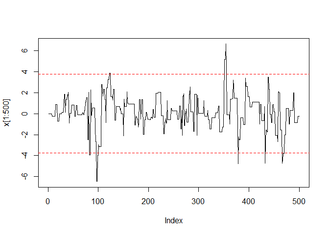

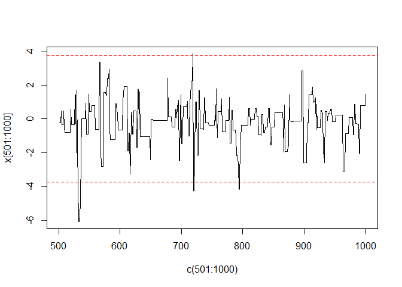

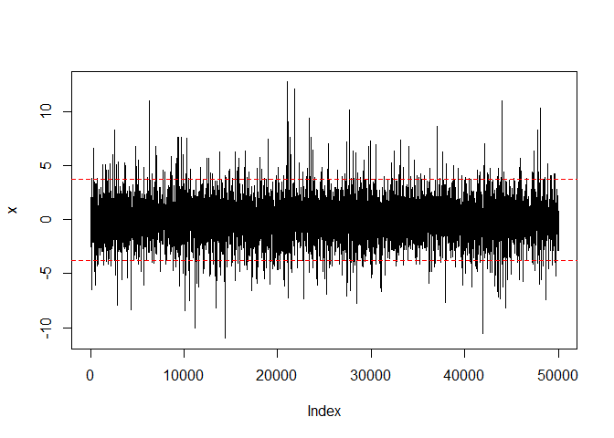

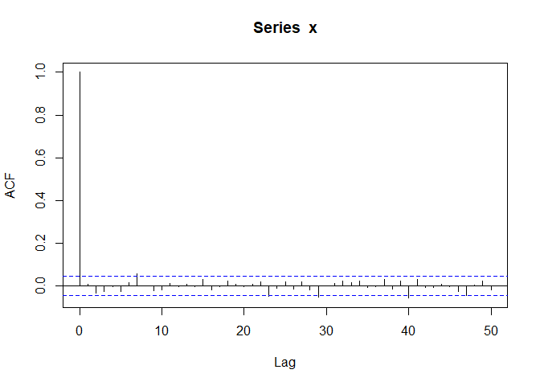

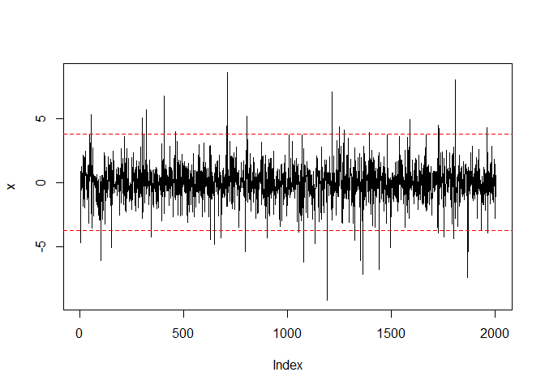

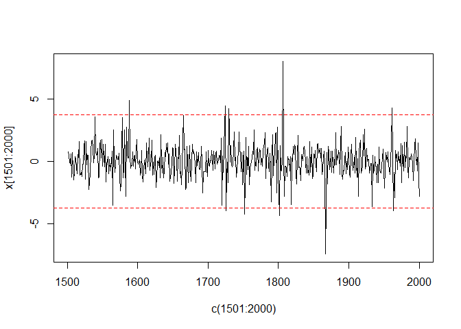

```
## [1] "Taxa de aceitação: "
## [1] 0.33562
```

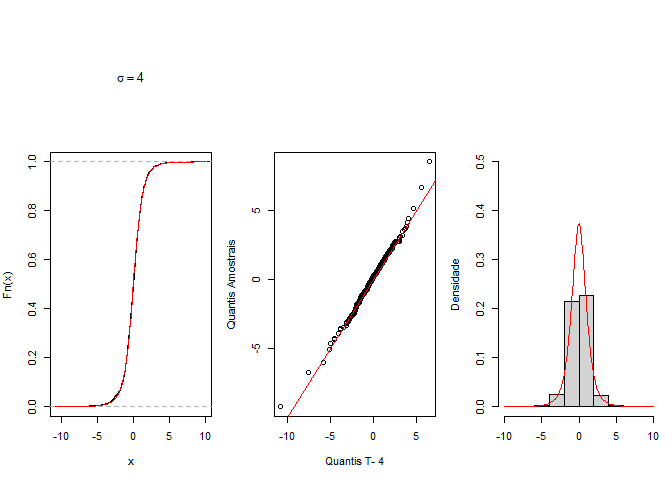

```r
tst_random_walk(sigma_g = 4, every_nth = 10)
```

## $N (0, 10)$

Por fim, temos o caso em que o amostrador tem como distribuição candidata uma Normal com desvio padrão bastante superior àqueles observados nos cenários anteriores, $N(0,10)$.

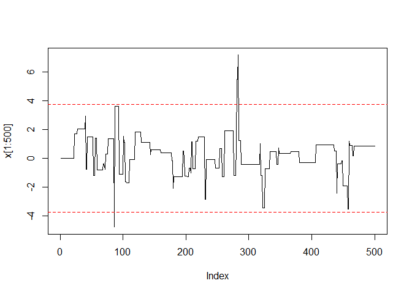

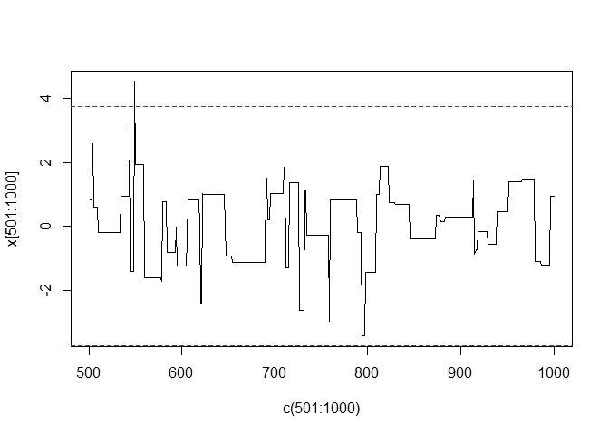

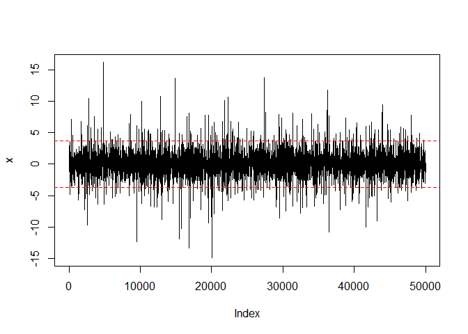

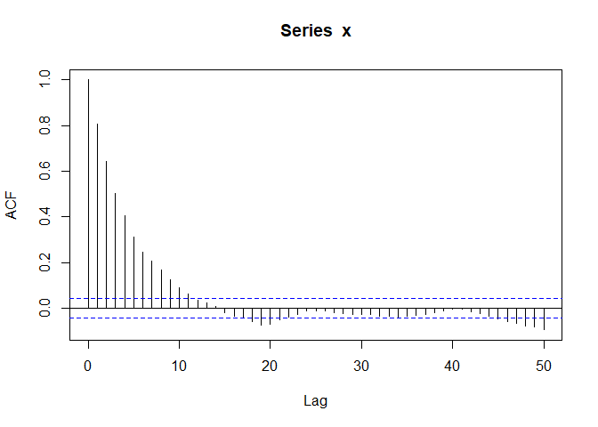

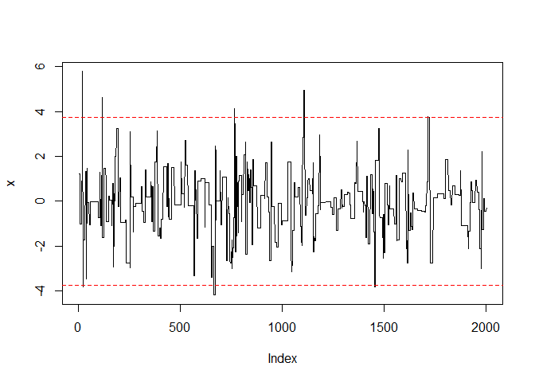

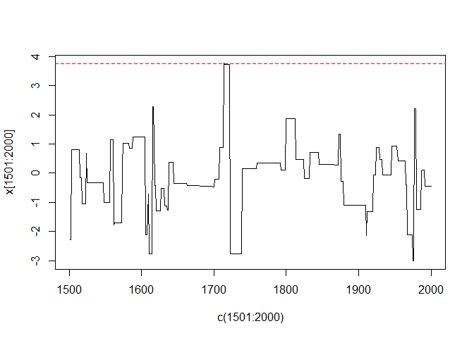

```
## [1] "Taxa de aceitação: "
## [1] 0.15506
```

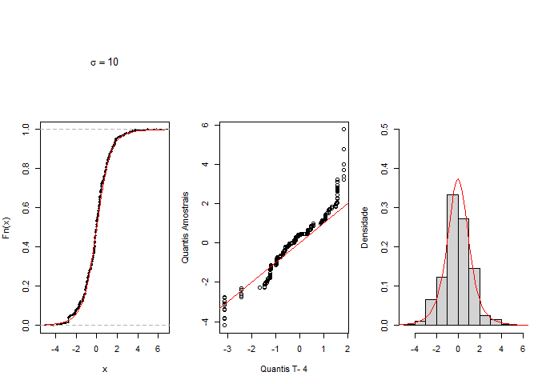

```r
tst_random_walk(sigma_g = 10)
```

- qual o melhor amostrador e porquê;
- retirar os primeiros valores p que não parecem fazer parte da distribuição alvo
- o que acontece à taxa de aceitação quando o desvio padrão é aumentado;
- o que acontece ao tempo até à convergência quando o desvio padrão é aumentado;
- o que acontece ao tempo até percorrer toda a amplitude de x quando o desvio padrão é aumentado;
- (?) o que acontece ao número de lags a partir do qual deixa de existir autocorrelação quando o desvio padrão é aumentado;
- o que acontece à semelhança com a distribuição teórica quando o desvio padrão é aumentado;
- propriedades das cadeias de Markov que são verificáveis
- cadeias de Markov convergem para o valor esperado (neste caso, a média das Normais candidatas)